# Data Analysis Using Statistical Packages: Organizing and Visualizing Data

Sho Kuroda / 黒田翔

最終更新：2026年5月

このページに対応するRmdファイル：[GitHub](https://github.com/kurodaecon/dasp/blob/main/rmd/organizing_data.Rmd)

# 1 Packages in R

パッケージには大別すると次の3種類がある：

1. Rをインストールした時に自動的にインストールされており，Rを起動したときにデフォルトで使えるように設定されているもの（`base::c`, `utils::str`, etc.）
2. Rをインストールした時に自動的にインストールされているが，Rを起動したときにデフォルトでは読み込まれていないもの（`MASS::Boston`, `Matrix::Cholesky`, etc.）
   - `library(パッケージ名)` で読み込んで `関数名` で呼び出すか，パッケージを読み込まずに `パッケージ名::関数名` で呼び出す
3. ユーザーが自分でインストールしなければ使えないもの（`tidyverse`, `data.table`, etc.）
   - `install.packages("パッケージ名")` でインストールし（最初の一度だけ実行），`library(パッケージ名)` で読み込む（Rを起動する度に実行）
   - RStudio で `install.packages` が使えない場合，PC がインターネットに接続されていることを確認したうえで，CRAN レポジトリを変更してリトライ：Tools > Global Options > Packages > Primary CRAN repository を 「Japan (Tokyo)」 などに変更（参考：[Setting CRAN repository options](https://blog.djnavarro.net/posts/2022-01-10_setting-cran-repositories/)）

補足：同じ名前の関数が複数のパッケージで使用されている場合があるので，常に `パッケージ名::関数名` の形式でパッケージを指定するのを好む人もいる．

## 1.1 `tidyverse` package

データの整理・操作は `tidyverse` というパッケージに含まれる関数を使うことが多い．

- 正確には，`tidyverse` は `dplyr` (読み方：“dee-ply-er”) や `ggplot2` などの複数のパッケージを束ねたもの
- `tidyverse` をインストール／ロードすれば `dplyr` や `ggplot2` などが同時にインストール／ロードされる

パッケージのインストールは R のインストール後に一度だけ実行する．

```r
install.packages("tidyverse")  # run for the first time only
```

インストール後に R に読み込む． こちらはパッケージのインストールと異なり，R （または RStudio）を起動するたびに実行する．

```r
library(tidyverse)
```

### 1.1.1 `dplyr` package

データのハンドリング（または data wrangling）を行うパッケージ．

- `filter` … 条件に合致する行を抽出
- `select` … 条件に合致する列（変数）を抽出
- `mutate` … 新しい列（変数）を作成
- `rename` … 列（変数）の名前を変更
- `left_join` … 2つのデータセットを統合
- `summarise` … データを要約
- `group_by` … 行をグルーピング
  - Note: `group_by` はそれ単体で使われるわけではなく，通常は `summarise` 関数と併用される

これらの関数は `%>%` で表される「パイプ」と呼ばれる演算子と組み合わせて利用されることが多い． このパイプは `tidyverse` パッケージ群を構成するパッケージの一つ `magrittr` によって提供されているが，この授業では細かいことを理解する必要はない．

### 1.1.2 `ggplot2` package

データ可視化のためのパッケージ． `plot` のようなデフォルトで使える関数と比べて文法に癖があるが，慣れれば論文に使える程度に綺麗な図を出力できる．

`plot` 関数はこれ単体でグラフを描画してくれるが，ggplot2 パッケージを使用する場合は `ggplot` 関数でデータと属性（X軸の変数，Y軸の変数，色に対応する変数，サイズに対応する変数）を指定し，次いで `geom_xxx` 関数でジオメトリ（点，線，棒，etc.）を指定するという2段階で描画する．

詳細は Kabacoff (2024) [Modern Data Visualization with R](https://rkabacoff.github.io/datavis/) などを参照．

# 2 Example using The Beatles data frame

## 2.1 Create “tibble” object

`data.frame` で作成したデータフレームのオブジェクトよりも少し扱いやすいデータフレーム型オブジェクトを `tibble::tibble` 関数で作成できる．

```r
beatles <- tibble::tibble(
  name = c("John", "Paul", "George", "Ringo"),
  born = c(1940, 1942, 1943, 1940),
  decease = c(1980, NA, NA, NA),
  height = c(179, 180, 178, 170)
  )
beatles
```

```
## # A tibble: 4 × 4
##   name    born decease height
##   <chr>  <dbl>   <dbl>  <dbl>
## 1 John    1940    1980    179
## 2 Paul    1942      NA    180
## 3 George  1943      NA    178
## 4 Ringo   1940      NA    170
```

## 2.2 Pipe `%>%`

`tidyverse` スタイルのデータハンドリングでは「パイプ（演算子）」と呼ばれるものが用いられる．

`%>%` （大なり記号をパーセント記号で挟んだもの）がパイプと呼ばれる．

「`data %>% function`」の形で使用し，パイプの前にある `data` をパイプの後の関数に渡す機能を持つ．

- `x %>% f()` は `f(x)` と（概ね）同じ．デフォルトでは関数の第一引数に渡す．
- `x %>% f(z)` は `f(x, z)` と（概ね）同じ．
- `z %>% f(x, .)` は `f(x, z)` と（概ね）同じ．第一引数以外の引数に渡す際は `.` を使う．

```r
mean(x = 1:2)  # これまでの書き方．mean(c(1, 2)) と同じ
```

```
## [1] 1.5
```

```r
1:2 %>% mean(x = .)  # "." でデータを受ける
```

```
## [1] 1.5
```

```r
1:2 %>% mean()  # . が1つ目の引数なら省略可
```

```
## [1] 1.5
```

```r
1:2 %>% mean  # () も省略可
```

```
## [1] 1.5
```

```r
c(1, 2, NA) %>% mean(na.rm = TRUE)  # option も指定可
```

```
## [1] 1.5
```

逐次的な処理をパイプを用いて表現することができる．

```r
sd(1:2)
```

```
## [1] 0.7071068
```

```r
round(sd(1:2), 2)
```

```
## [1] 0.71
```

```r
1:2 %>% sd() %>% round(2)
```

```
## [1] 0.71
```

以下のようにネストが深い場合はパイプを使うことで処理の順序が理解しやすくなる．

$$\frac{1}{n} \sum_i \log_{10} \sqrt{
|x_i| } \quad \mbox{を小数第2位まで表示}$$

```r
round(mean(log(sqrt(abs(rnorm(n = 1000, mean = 1))), base = 10), na.rm = TRUE), 2)
```

```
## [1] -0.07
```

```r
rnorm(n = 1000, mean = 1) %>% abs %>% sqrt %>% log(base = 10) %>% mean(na.rm = TRUE) %>% round(2)
```

```
## [1] -0.04
```

要するに，パイプを使う目的は，全く新しい種類の計算をすることではなく，既存の計算処理を順序通りに記述する（パイプライン処理する）ことにある．

- コードの可読性が高まることで保守・デバッグが容易になるのに加え，計算内容を第三者が検証するうえでも役立つ．
- このアイデアはR特有ではなく，UNIXのパイプなど先行する機能に着想を得て実装されたものと思われる．
- パイプは `tidyverse` で提供される関数と組み合わせて以下のサブセクションのように使われることが一般的．

## 2.3 `filter`

残す行（observation）の条件を指定する．

```r
beatles %>% filter(born >= 1941)  # 一般的な書き方
```

```
## # A tibble: 2 × 4
##   name    born decease height
##   <chr>  <dbl>   <dbl>  <dbl>
## 1 Paul    1942      NA    180
## 2 George  1943      NA    178
```

```r
filter(beatles, born >= 1941)  # 計算結果は同じ
```

```
## # A tibble: 2 × 4
##   name    born decease height
##   <chr>  <dbl>   <dbl>  <dbl>
## 1 Paul    1942      NA    180
## 2 George  1943      NA    178
```

```r
beatles[beatles$born >= 1941, ]  # もちろんこれも同じ
```

```
## # A tibble: 2 × 4
##   name    born decease height
##   <chr>  <dbl>   <dbl>  <dbl>
## 1 Paul    1942      NA    180
## 2 George  1943      NA    178
```

`filter` を適用した後のデータセットを新しいオブジェクトに割り当てるには `<-` を用いる．

```r
beatles_ver2 <- beatles %>% filter(born >= 1941)
beatles_ver2
```

```
## # A tibble: 2 × 4
##   name    born decease height
##   <chr>  <dbl>   <dbl>  <dbl>
## 1 Paul    1942      NA    180
## 2 George  1943      NA    178
```

以下のようにすれば元のオブジェクトを上書きすることも可能（以下同様）．

```r
# beatles <- beatles %>% filter(born >= 1941)
# beatles %<>% filter(born >= 1941)  # same as above
```

複数の条件を指定することもできる．

```r
beatles %>% filter(born >= 1941 & height < 180)
```

```
## # A tibble: 1 × 4
##   name    born decease height
##   <chr>  <dbl>   <dbl>  <dbl>
## 1 George  1943      NA    178
```

## 2.4 `select`

残す列（変数）の名前を指定する．

```r
beatles %>% select(name)
```

```
## # A tibble: 4 × 1
##   name
##   <chr>
## 1 John
## 2 Paul
## 3 George
## 4 Ringo
```

```r
beatles %>% select(name, born)
```

```
## # A tibble: 4 × 2
##   name    born
##   <chr>  <dbl>
## 1 John    1940
## 2 Paul    1942
## 3 George  1943
## 4 Ringo   1940
```

マイナス記号 `-` を使って「`-変数名`」と指定すると当該変数以外が残る．

```r
beatles %>% select(-height)
```

```
## # A tibble: 4 × 3
##   name    born decease
##   <chr>  <dbl>   <dbl>
## 1 John    1940    1980
## 2 Paul    1942      NA
## 3 George  1943      NA
## 4 Ringo   1940      NA
```

## 2.5 `mutate`

新しく列（変数）を作成する．

```r
beatles %>% mutate(primary_role = c("vocal", "vocal", "guitar", "drum"))
```

```
## # A tibble: 4 × 5
##   name    born decease height primary_role
##   <chr>  <dbl>   <dbl>  <dbl> <chr>
## 1 John    1940    1980    179 vocal
## 2 Paul    1942      NA    180 vocal
## 3 George  1943      NA    178 guitar
## 4 Ringo   1940      NA    170 drum
```

既存の変数を利用して新しい変数を作成することもできる．

```r
beatles %>% mutate(age_at_debut = 1962 - born)
```

```
## # A tibble: 4 × 5
##   name    born decease height age_at_debut
##   <chr>  <dbl>   <dbl>  <dbl>        <dbl>
## 1 John    1940    1980    179           22
## 2 Paul    1942      NA    180           20
## 3 George  1943      NA    178           19
## 4 Ringo   1940      NA    170           22
```

## 2.6 `rename`

列（変数）の名前を変える．

```r
beatles %>% rename(birth_year = born)
```

```
## # A tibble: 4 × 4
##   name   birth_year decease height
##   <chr>       <dbl>   <dbl>  <dbl>
## 1 John         1940    1980    179
## 2 Paul         1942      NA    180
## 3 George       1943      NA    178
## 4 Ringo        1940      NA    170
```

## 2.7 `left_join`

別のデータセットと統合する．

```r
beatles_primary_role <- tibble::tibble(name = c("John", "Paul", "George", "Ringo"),
                                       primary_role = c("vocal", "vocal", "guitar", "drum"))
beatles_primary_role
```

```
## # A tibble: 4 × 2
##   name   primary_role
##   <chr>  <chr>
## 1 John   vocal
## 2 Paul   vocal
## 3 George guitar
## 4 Ringo  drum
```

```r
beatles %>% left_join(beatles_primary_role, by = "name")
```

```
## # A tibble: 4 × 5
##   name    born decease height primary_role
##   <chr>  <dbl>   <dbl>  <dbl> <chr>
## 1 John    1940    1980    179 vocal
## 2 Paul    1942      NA    180 vocal
## 3 George  1943      NA    178 guitar
## 4 Ringo   1940      NA    170 drum
```

### 2.7.1 If some key exists in only one of the data frames / 片方のデータフレームにしかないキーがある場合

一方のデータフレームにしかないキー（ID）がある場合，主たるデータフレーム（左側にある，マージされる側）の行はそのまま残る．

補足：コードの文法上左側にあるデータセットに合わせてマージするので `left_join` という関数名が使われている．右側に合わせる場合は `right_join`，積集合でマージするのは `inner_join`，和集合でマージするのは `full_join`．

Case 1. 担当楽器のデータセット（右側）に対応する行がない場合．

```r
beatles_primary_role_wo_paul <- tibble::tibble(name = c("John", "George", "Ringo"),
                                               primary_role = c("vocal", "guitar", "drum"))
beatles_primary_role_wo_paul
```

```
## # A tibble: 3 × 2
##   name   primary_role
##   <chr>  <chr>
## 1 John   vocal
## 2 George guitar
## 3 Ringo  drum
```

```r
beatles %>% left_join(beatles_primary_role_wo_paul, by = "name")
```

```
## # A tibble: 4 × 5
##   name    born decease height primary_role
##   <chr>  <dbl>   <dbl>  <dbl> <chr>
## 1 John    1940    1980    179 vocal
## 2 Paul    1942      NA    180 <NA>
## 3 George  1943      NA    178 guitar
## 4 Ringo   1940      NA    170 drum
```

Case 2. 逆に，主なデータフレーム（左側）の方に一部の行が存在しない場合．

```r
beatles %>%
  filter(name != "Paul") %>%
  left_join(beatles_primary_role, by = "name")
```

```
## # A tibble: 3 × 5
##   name    born decease height primary_role
##   <chr>  <dbl>   <dbl>  <dbl> <chr>
## 1 John    1940    1980    179 vocal
## 2 George  1943      NA    178 guitar
## 3 Ringo   1940      NA    170 drum
```

## 2.8 `summarise`

データを要約する．

```r
beatles %>% summarise(mean_height = mean(height),
                      std_dev_height = sd(height),
                      sample_size = n())
```

```
## # A tibble: 1 × 3
##   mean_height std_dev_height sample_size
##         <dbl>          <dbl>       <int>
## 1        177.           4.57           4
```

## 2.9 `group_by`

`summarise` 関数と組み合わせて使うことで，グループごとの要約統計量を計算したり何らかの統計処理を行うことができる．

```r
beatles %>%
  group_by(born) %>%
  summarise(mean_height = mean(height),
            std_dev_height = sd(height),  # n=1 なら sd=NA
            sample_size = n())
```

```
## # A tibble: 3 × 4
##    born mean_height std_dev_height sample_size
##   <dbl>       <dbl>          <dbl>       <int>
## 1  1940        174.           6.36           2
## 2  1942        180           NA              1
## 3  1943        178           NA              1
```

## 2.10 Scatter plot

まずは `ggplot` だけ実行してみる． データが何も描かれていないキャンバスだけが表示される．

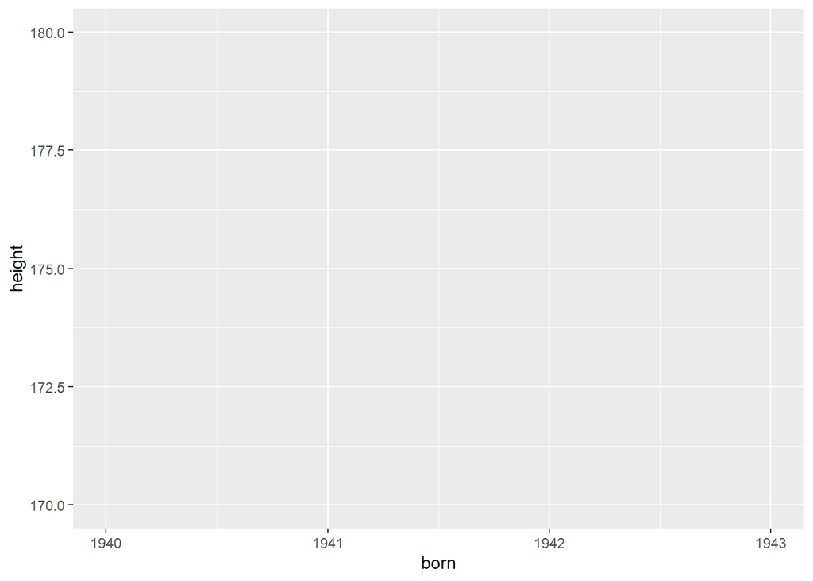

```r
ggplot(data = beatles, mapping = aes(x = born, y = height))
```

ここに点のレイヤーを `geom_point` 関数で追加する．

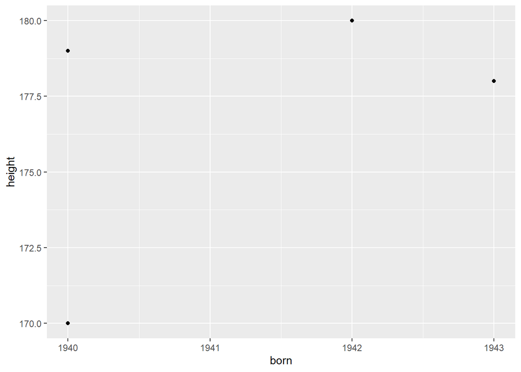

```r
ggplot(data = beatles, mapping = aes(x = born, y = height)) +
  geom_point()
```

軸のラベルを変更する．

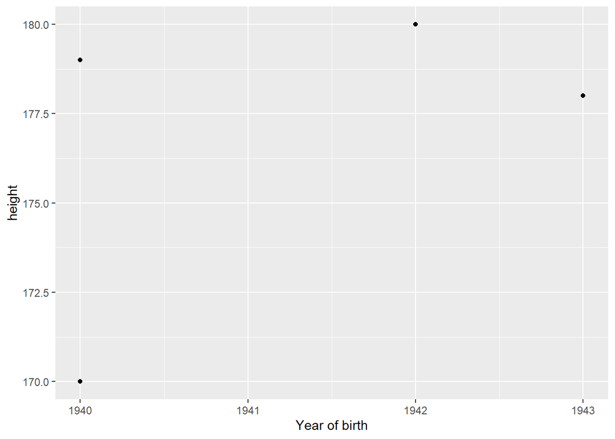

```r
ggplot(data = beatles, mapping = aes(x = born, y = height)) +
  geom_point() +
  xlab("Year of birth")  # または labs(x = "...", y = "...")
```

キャンバスのテーマを変える．

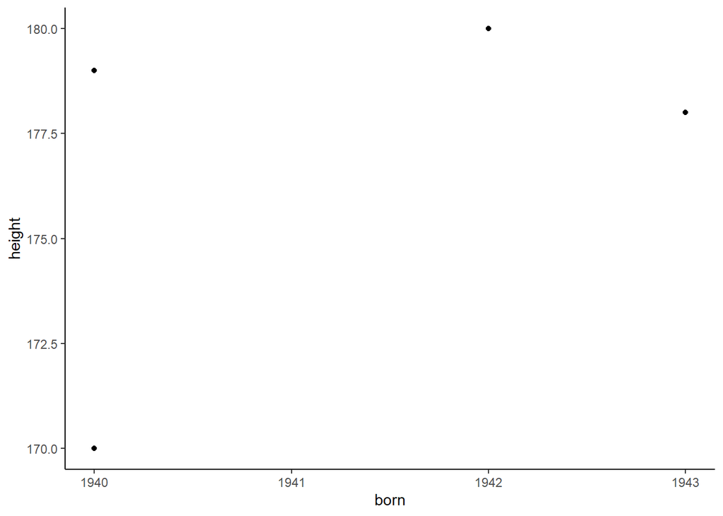

```r
ggplot(data = beatles, mapping = aes(x = born, y = height)) +
  geom_point() +
  theme_classic()
```

# 3 Example using Titanic data

```r
titanic <- read.csv("https://raw.githubusercontent.com/kurodaecon/bs/main/data/titanic3_csv.csv")
```

## 3.1 `filter`

```r
titanic %>% filter(age > 75)  # NA は FALSE 扱い
```

```
##   pclass survived    sex age sibsp parch  fare embarked
## 1      1        1   male  80     0     0 30.00        S
## 2      1        1 female  76     1     0 78.85        S
```

## 3.2 `group_by` and `summarise`

性別ごとの生存率．

```r
titanic %>%
  group_by(sex) %>%
  summarise(survival_rate = mean(survived),
            sample_size = n())
```

```
## # A tibble: 2 × 3
##   sex    survival_rate sample_size
##   <chr>          <dbl>       <int>
## 1 female         0.727         466
## 2 male           0.191         843
```

性別と客室等級ごとの生存率．

```r
titanic %>%
  group_by(sex, pclass) %>%
  summarise(survival_rate = mean(survived),
            sample_size = n())
```

```
## # A tibble: 6 × 4
## # Groups:   sex [2]
##   sex    pclass survival_rate sample_size
##   <chr>   <int>         <dbl>       <int>
## 1 female      1         0.965         144
## 2 female      2         0.887         106
## 3 female      3         0.491         216
## 4 male        1         0.341         179
## 5 male        2         0.146         171
## 6 male        3         0.152         493
```

性別と年齢層ごとの生存率．

```r
titanic %>%
  mutate(age_group = cut(age, breaks = c(0, 20, 60, 100), right = FALSE)) %>%
  group_by(sex, age_group) %>%
  summarise(survival_rate = mean(survived),
            sample_size = n())
```

```
## # A tibble: 8 × 4
## # Groups:   sex [2]
##   sex    age_group survival_rate sample_size
##   <chr>  <fct>             <dbl>       <int>
## 1 female [0,20)            0.699         103
## 2 female [20,60)           0.770         274
## 3 female [60,100)          0.818          11
## 4 female <NA>              0.603          78
## 5 male   [0,20)            0.279         122
## 6 male   [20,60)           0.193         507
## 7 male   [60,100)          0.103          29
## 8 male   <NA>              0.141         185
```

性別と客室等級と年齢層ごとの生存率．

```r
titanic %>%
  mutate(age_group = cut(age, breaks = c(0, 20, 60, 100), right = FALSE)) %>%
  group_by(sex, pclass, age_group) %>%
  summarise(survival_rate = mean(survived),
            sample_size = n())
```

```
## # A tibble: 24 × 5
## # Groups:   sex, pclass [6]
##    sex    pclass age_group survival_rate sample_size
##    <chr>   <int> <fct>             <dbl>       <int>
##  1 female      1 [0,20)            0.938          16
##  2 female      1 [20,60)           0.972         108
##  3 female      1 [60,100)          0.889           9
##  4 female      1 <NA>              1              11
##  5 female      2 [0,20)            0.958          24
##  6 female      2 [20,60)           0.885          78
##  7 female      2 [60,100)          0               1
##  8 female      2 <NA>              0.667           3
##  9 female      3 [0,20)            0.540          63
## 10 female      3 [20,60)           0.420          88
## # ℹ 14 more rows
```

カテゴリー数が多いためにすべて表示されていない． 以下のように表示数を調整できる．

```r
titanic %>%
  mutate(age_group = cut(age, breaks = c(0, 20, 60, 100), right = FALSE)) %>%
  group_by(sex, pclass, age_group) %>%
  summarise(survival_rate = mean(survived),
            sample_size = n()) %>%
  print(n = 30)
```

```
## # A tibble: 24 × 5
## # Groups:   sex, pclass [6]
##    sex    pclass age_group survival_rate sample_size
##    <chr>   <int> <fct>             <dbl>       <int>
##  1 female      1 [0,20)           0.938           16
##  2 female      1 [20,60)          0.972          108
##  3 female      1 [60,100)         0.889            9
##  4 female      1 <NA>             1               11
##  5 female      2 [0,20)           0.958           24
##  6 female      2 [20,60)          0.885           78
##  7 female      2 [60,100)         0                1
##  8 female      2 <NA>             0.667            3
##  9 female      3 [0,20)           0.540           63
## 10 female      3 [20,60)          0.420           88
## 11 female      3 [60,100)         1                1
## 12 female      3 <NA>             0.531           64
## 13 male        1 [0,20)           0.6             10
## 14 male        1 [20,60)          0.363          124
## 15 male        1 [60,100)         0.118           17
## 16 male        1 <NA>             0.286           28
## 17 male        2 [0,20)           0.444           27
## 18 male        2 [20,60)          0.0806         124
## 19 male        2 [60,100)         0.143            7
## 20 male        2 <NA>             0.154           13
## 21 male        3 [0,20)           0.188           85
## 22 male        3 [20,60)          0.166          259
## 23 male        3 [60,100)         0                5
## 24 male        3 <NA>             0.111          144
```

年齢の平均を計算しようとすると `NA` が返ってくる．

```r
titanic %>%
  summarise(age_mean = mean(age))
```

```
##   age_mean
## 1       NA
```

これは年齢変数 `age` に `NA` が含まれるため． `na.rm = TRUE` 引数を追加する．

```r
titanic %>%
  summarise(age_mean = mean(age, na.rm = TRUE))
```

```
##   age_mean
## 1 29.88114
```

## 3.3 Correlation matrix

相関係数行列．

```r
titanic %>%
  select(age, fare, parch) %>%
  cor(use = "complete.obs")
```

```
##              age      fare      parch
## age    1.0000000 0.1787399 -0.1502409
## fare   0.1787399 1.0000000  0.2167232
## parch -0.1502409 0.2167232  1.0000000
```

## 3.4 Histogram using `ggplot2`

年齢．

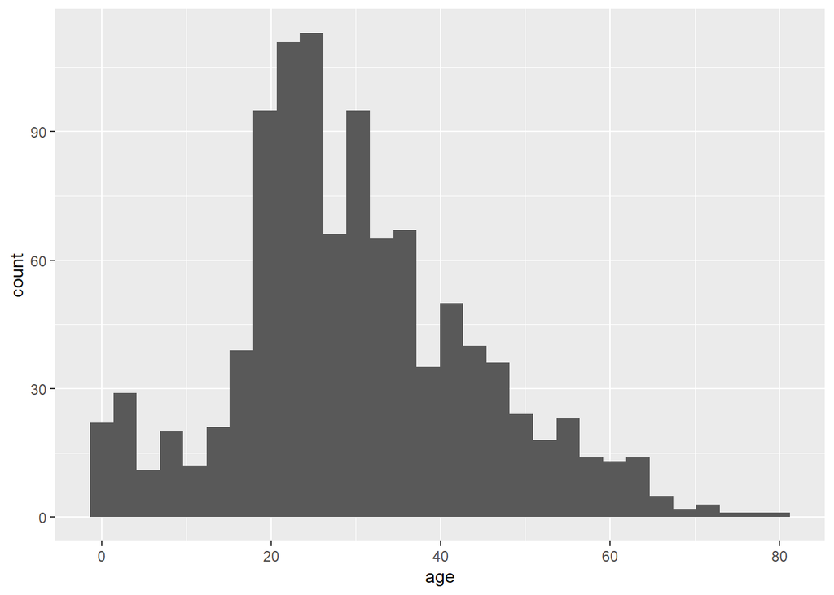

```r
ggplot(data = titanic, mapping = aes(x = age)) +
  geom_histogram()
```

性別ごとに分ける．

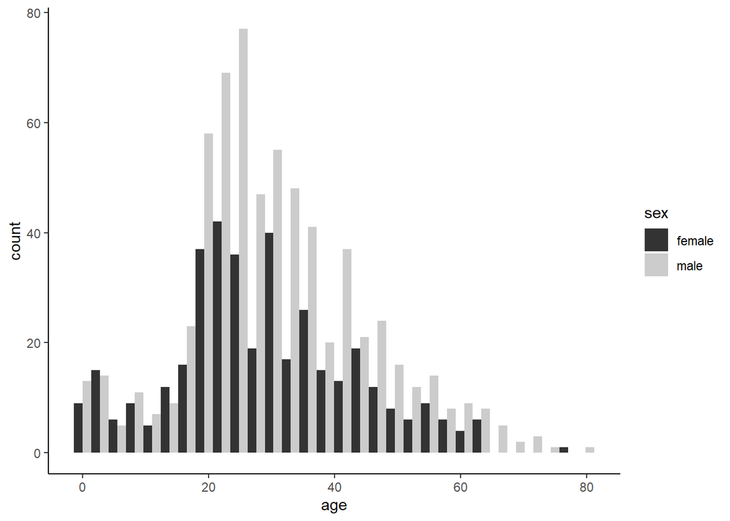

```r
ggplot(data = titanic, mapping = aes(x = age, fill = sex)) +
  geom_histogram(position = "dodge") +
  scale_fill_grey() +  # grey scale
  theme_classic()
```

## 3.5 Bar plot using `ggplot2`

出港地ごとの人数．

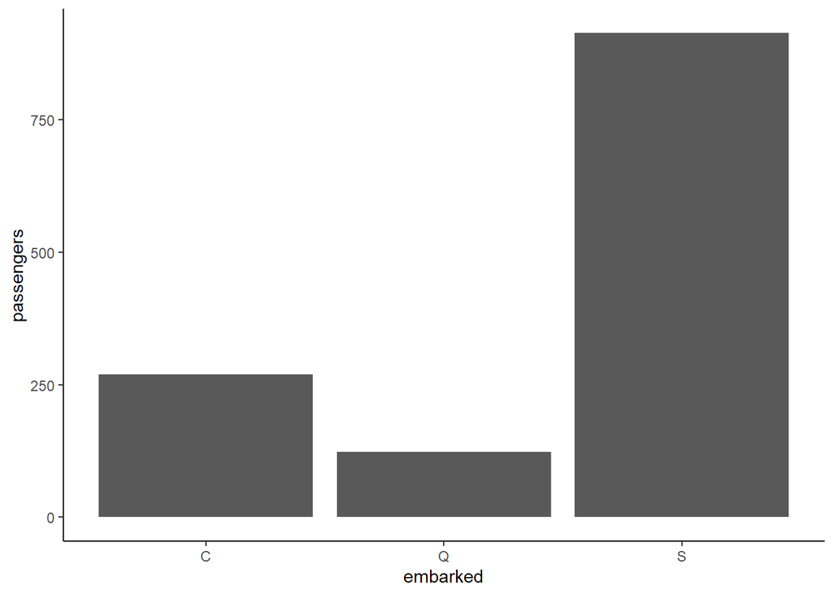

```r
titanic %>%
  filter(embarked != "") %>%
  group_by(embarked) %>%
  summarise(passengers = n()) %>%
  ggplot(mapping = aes(x = embarked, y = passengers)) +
  geom_bar(stat = "identity") +  # または geom_col()
  theme_classic()
```

性別ごとに分ける． ついでにX軸のラベルも修正しておく．

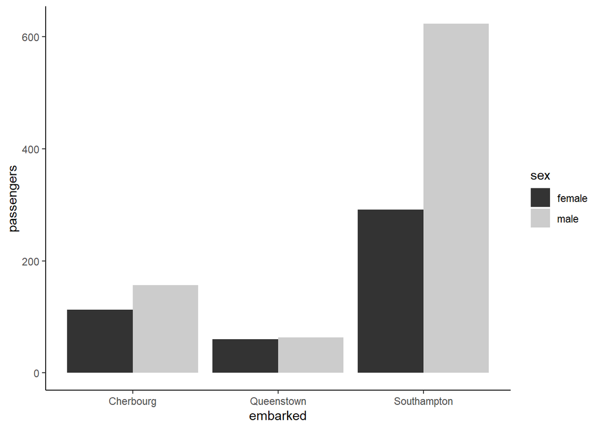

```r
titanic %>%
  filter(embarked != "") %>%
  group_by(embarked, sex) %>%
  summarise(passengers = n()) %>%
  ggplot(mapping = aes(x = embarked, y = passengers, fill = sex)) +
  geom_bar(stat = "identity", position = "dodge") +
  scale_x_discrete(labels = c(C = "Cherbourg", Q = "Queenstown", S = "Southampton")) +
  scale_fill_grey() +
  theme_classic()
```

## 3.6 Pie chart using `ggplot2`

出港地ごとの人数．

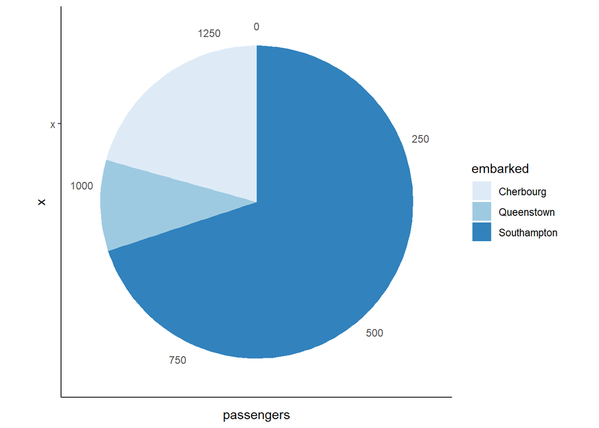

```r
titanic %>%
  filter(embarked != "") %>%
  group_by(embarked) %>%
  summarise(passengers = n()) %>%
  ggplot(mapping = aes(x = "x", y = passengers, fill = embarked)) +
  geom_bar(stat = "identity", position = "stack") +
  coord_polar(theta = "y") +
  scale_fill_brewer(labels = c("Cherbourg", "Queenstown", "Southampton")) +
  theme_classic()
```

## 3.7 Boxplot using `ggplot2`

性別ごとの年齢．

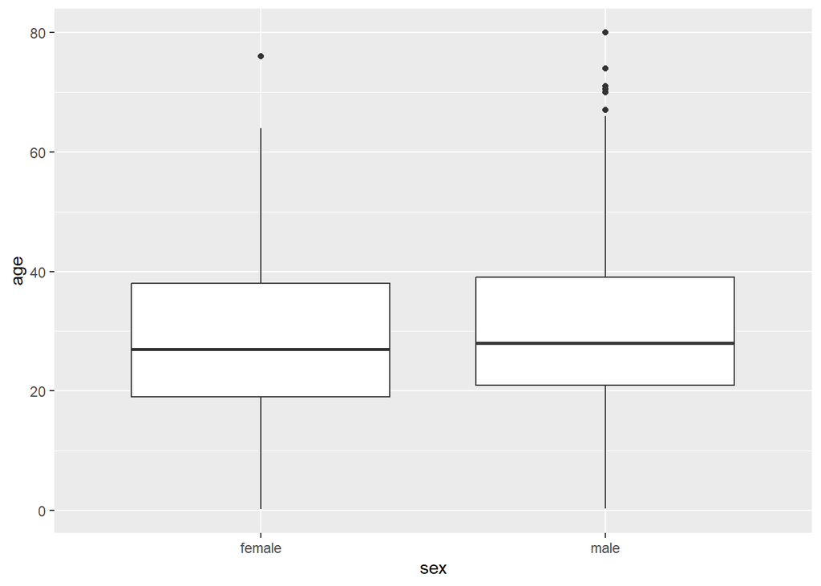

```r
ggplot(data = titanic, mapping = aes(x = sex, y = age)) +
  geom_boxplot()
```

性別・客室等級ごとの年齢．

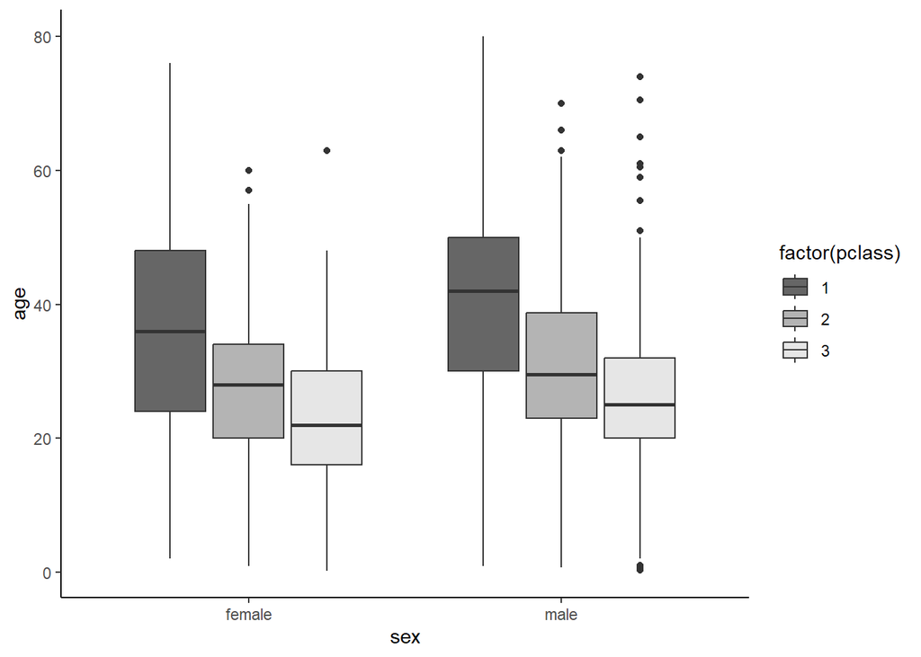

```r
ggplot(data = titanic, mapping = aes(x = sex, y = age, fill = factor(pclass))) +
  geom_boxplot() +
  scale_fill_grey(start = 0.4, end = 0.9) +
  theme_classic()
```

データの分布が複雑な場合（多峰など），バイオリンプロットという選択肢がある．

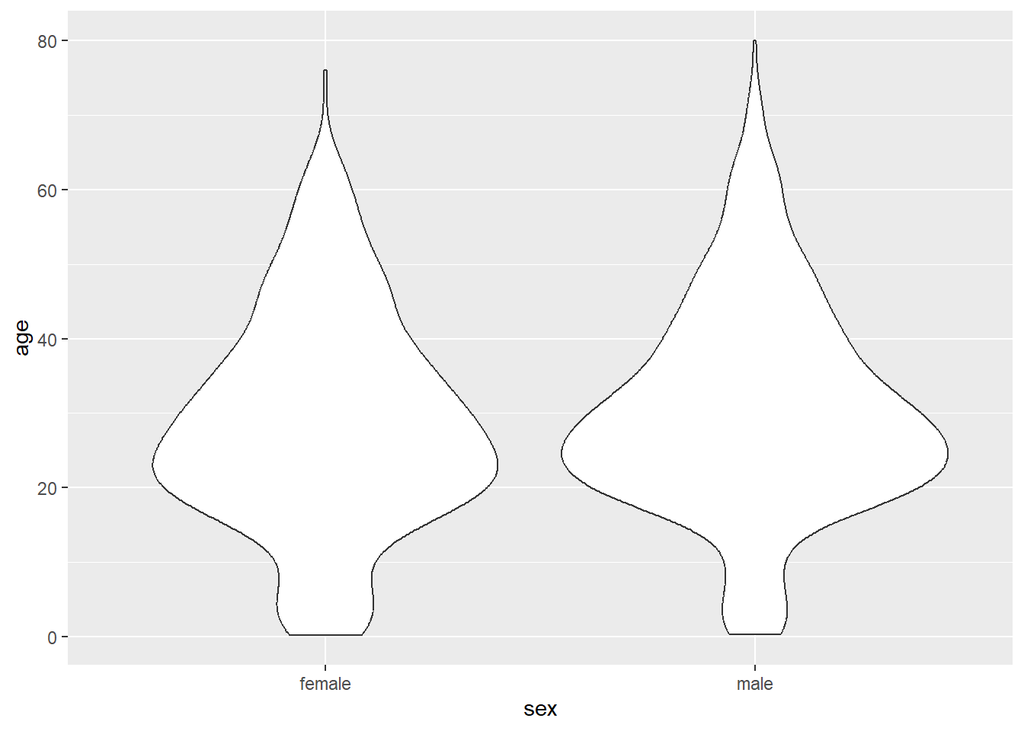

```r
ggplot(data = titanic, mapping = aes(x = sex, y = age)) +
  geom_violin()
```

## 3.8 Scatter plot using `ggplot2`

点同士が重なってしまうため `geom_jitter` 関数でY軸方向にばらつかせて描画．

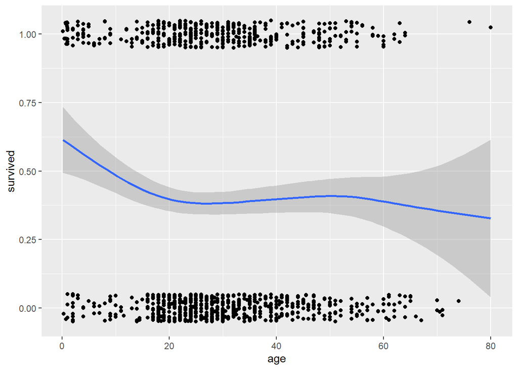

```r
ggplot(data = titanic, mapping = aes(x = age, y = survived)) +
  geom_jitter(height = .05, width = 0) +
  geom_smooth()
```

Y軸の `survived` は 0/1 の binary 変数なので jitter は違和感がある． Binned plot はよい代替案だろう．

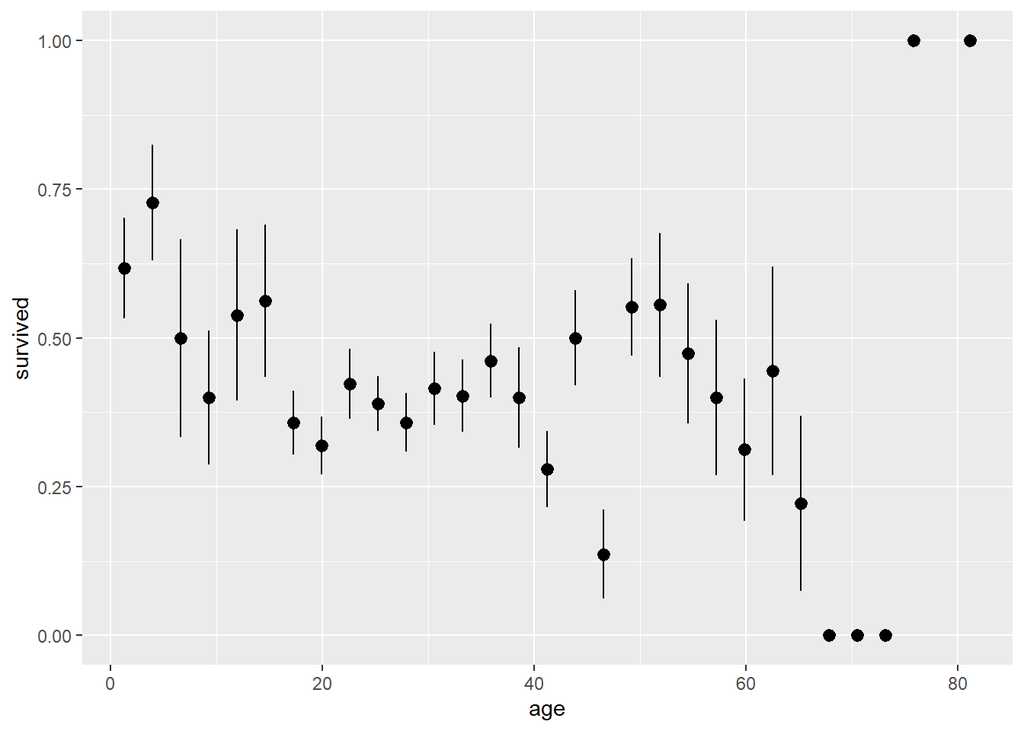

```r
ggplot(data = titanic, mapping = aes(x = age, y = survived)) +
  stat_summary_bin()
```

性別による生存率の違いを示す．

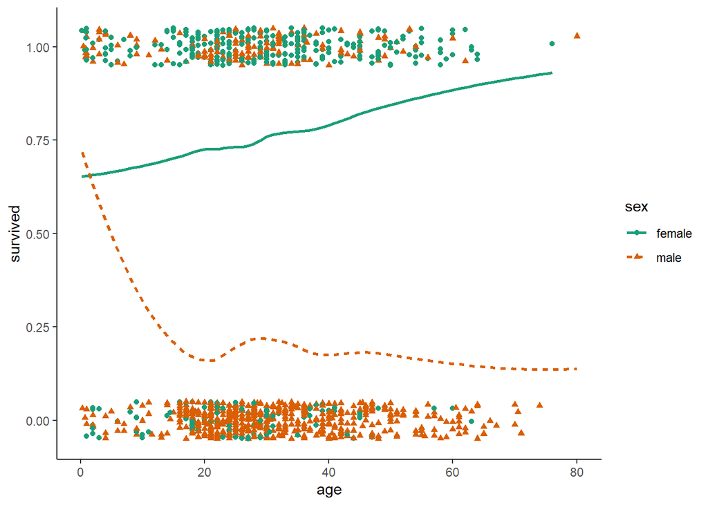

```r
ggplot(data = titanic, mapping = aes(x = age, y = survived, color = sex, shape = sex, linetype = sex)) +
  geom_jitter(height = .05, width = 0) +
  geom_smooth(se = FALSE) +
  scale_color_brewer(palette = "Dark2") + # colorblind-friendly palette
  theme_classic()
```

客室等級による生存率の違いを示す．

- `pclass` は数値として記録されている質的変数（順序尺度）なので `factor` 関数で因子型の変数に変換して使う．

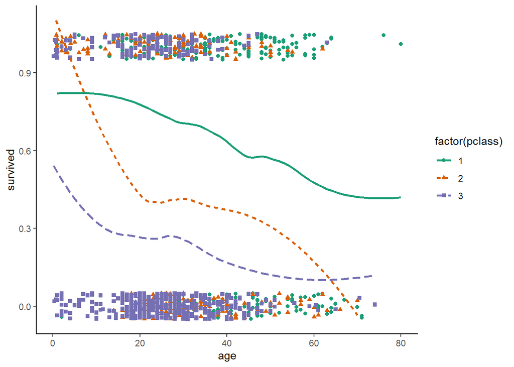

```r
ggplot(data = titanic, mapping = aes(x = age, y = survived, color = factor(pclass),
                                     shape = factor(pclass), linetype = factor(pclass))) +
  geom_jitter(height = .05, width = 0) +
  geom_smooth(se = FALSE) +
  scale_color_brewer(palette = "Dark2") +
  theme_classic()
```

# 4 Pipe in base R

Base R （Rインストール時にbuilt-inされている標準パッケージのみを使用し，追加のパッケージを手動でインストールしない状態）でもパイプ演算子が使える．

- これは比較的新しい機能．`tidyverse` スタイルの `%>%` を用いたデータハンドリングが普及したことを受けて2021年頃に実装された．
- Base R のパイプは `|>` （縦棒と大なり記号を組み合わせたもの）と書く．
- パイプ `|>` を `base::subset` や `base::transform` などの base R の関数と組み合わせて使えば，`tidyverse` パッケージなしで `tidyverse` に似た方法で処理を記述することができる．

## 4.1 Pipe `|>`

`|>` は `%>%` と同様に直前の値を関数の第一引数に渡す．

```r
1:2 |> mean(x = _)  # "_" でデータを受ける
```

```
## [1] 1.5
```

```r
1:2 |> mean()  # _ が1つ目の引数なら省略可（注：カッコは省略不可）
```

```
## [1] 1.5
```

```r
c(1, 2, NA) |> mean(na.rm = TRUE)  # option も指定可
```

```
## [1] 1.5
```

```r
titanic |> head(2)
```

```
##   pclass survived    sex   age sibsp parch     fare embarked
## 1      1        1 female 29.00     0     0 211.3375        S
## 2      1        1   male  0.92     1     2 151.5500        S
```

```r
titanic[, c("survived", "age")] |> cor(use = "complete.obs") |> round(2)
```

```
##          survived   age
## survived     1.00 -0.06
## age         -0.06  1.00
```

## 4.2 `subset` corresponding to `filter`

```r
titanic %>% dplyr::filter(age >= 75)
```

```
##   pclass survived    sex age sibsp parch  fare embarked
## 1      1        1   male  80     0     0 30.00        S
## 2      1        1 female  76     1     0 78.85        S
```

```r
titanic |> base::subset(age >= 75)
```

```
##    pclass survived    sex age sibsp parch  fare embarked
## 15      1        1   male  80     0     0 30.00        S
## 62      1        1 female  76     1     0 78.85        S
```

## 4.3 `transform` corresponding to `mutate`

```r
titanic %>% dplyr::mutate(family = sibsp + parch) %>% head(2)
```

```
##   pclass survived    sex   age sibsp parch     fare embarked family
## 1      1        1 female 29.00     0     0 211.3375        S      0
## 2      1        1   male  0.92     1     2 151.5500        S      3
```

```r
titanic |> base::transform(family = sibsp + parch) |> head(2)
```

```
##   pclass survived    sex   age sibsp parch     fare embarked family
## 1      1        1 female 29.00     0     0 211.3375        S      0
## 2      1        1   male  0.92     1     2 151.5500        S      3
```

## 4.4 `aggregate` corresponding to `group_by` + `summarise`

```r
titanic %>% dplyr::group_by(pclass) %>% dplyr::summarise(survived_rate = mean(survived))
```

```
## # A tibble: 3 × 2
##   pclass survived_rate
##    <int>         <dbl>
## 1      1         0.619
## 2      2         0.430
## 3      3         0.255
```

```r
titanic |> stats::aggregate(survived ~ pclass, data = _, FUN = mean)
```

```
##   pclass  survived
## 1      1 0.6191950
## 2      2 0.4296029
## 3      3 0.2552891
```

複数の変数を基準として集計することも可能（出力は省略）．

```r
titanic %>% dplyr::group_by(pclass, sex) %>% dplyr::summarise(survived_rate = mean(survived))
titanic |> stats::aggregate(survived ~ pclass + sex, data = _, FUN = mean)
```

注：上記の対比だけを見ると `tidyverse` スタイルのデータ処理が不要であるかのように見えるかもしれないが，実際にはそんなことはない． 上記のような単純な処理であれば Base R の標準的な関数だけでも事足りる場合もあるが，複雑な処理をする上では `tidyverse` を使った方がよい．